# Intro to NN Project Rathi S Part A

Training is the process of adjusting the parameters of a neural network to minimize a cost function. Validation is the process of measuring the accuracy of a model on a subset of the data. Accuracy is a measure of how well a model is able to predict the correct output given the input.

```python
import matplotlib.pyplot as plt
```

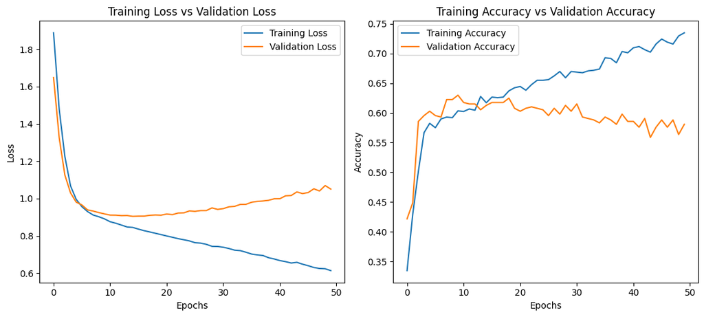

```python
plt.figure(figsize=(11, 5))

# Plots training loss and validation loss
plt.subplot(1, 2, 1)
plt.plot(model_classifier.history['loss'], label='Training Loss')
plt.plot(model_classifier.history['val_loss'], label='Validation Loss')
plt.title('Training Loss vs Validation Loss')
plt.xlabel('Epochs')
plt.ylabel('Loss')
plt.legend()

# Plots training accuracy and validation accuracy
plt.subplot(1, 2, 2)
plt.plot(model_classifier.history['accuracy'], label='Training Accuracy')
plt.plot(model_classifier.history['val_accuracy'], label='Validation Accuracy')
plt.title('Training Accuracy vs Validation Accuracy')
plt.xlabel('Epochs')
plt.ylabel('Accuracy')
plt.legend()

plt.tight_layout()
plt.show()
```

Part A - Q3 D - Design new architecture/update existing architecture in attempt to improve the performance of the model.

```python
!pip install tensorflow
import tensorflow as tf
from tensorflow.keras.layers import Dense, Dropout
from tensorflow.keras.models import Sequential
```

```python
# Define a new model with dropout layers
model = Sequential()
model.add(Dense(64, activation='relu', input_shape=(11,)))
model.add(Dropout(0.5))
# Here we can see the dropout parameter as 0.5 which means that half of the given units will drop out.
model.add(Dense(32, activation='relu'))
model.add(Dropout(0.5))
model.add(Dense(8, activation='softmax'))

model.compile(optimizer='adam', loss='categorical_crossentropy', metrics=['accuracy'])
```

```python
print(f"y_pred shape: {model.predict(X_Test_S).shape}")
print(f"y_true shape: {YC_test.shape}")
```

```
y_pred shape: (408, 8)
y_true shape: (408, 8)
```

```python
model.layers[-1] = tf.keras.layers.Dense(8, activation='softmax')
```

```python
# Train the classifier with the updated architecture
model_classifier=model.fit(X_Train_S, YC_train, validation_data=(X_Test_S,YC_test), epochs=50, batch_size=32)
```

Part A - Q3 E - Plot visuals as in Q3.C and share insights about difference observed in both the models.

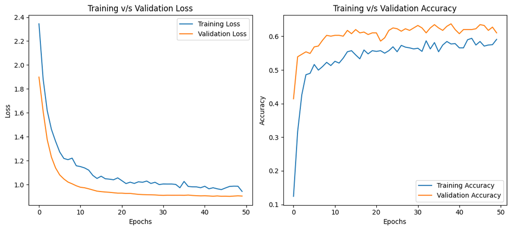

```python
plt.figure(figsize=(11, 5))

# Plots training loss and validation loss
plt.subplot(1, 2, 1)
plt.plot(model_classifier.history['loss'], label='Training Loss')
plt.plot(model_classifier.history['val_loss'], label='Validation Loss')
plt.title('Training v/s Validation Loss')
plt.xlabel('Epochs')
plt.ylabel('Loss')
plt.legend()

# Plots training accuracy and validation accuracy
plt.subplot(1, 2, 2)
plt.plot(model_classifier.history['accuracy'], label='Training Accuracy')
plt.plot(model_classifier.history['val_accuracy'], label='Validation Accuracy')
plt.title('Training v/s Validation Accuracy')
plt.xlabel('Epochs')
plt.ylabel('Accuracy')
plt.legend()

plt.tight_layout()
plt.show()
```

Insights about differences observed in both models

Training Loss vs Validation Loss:

The Original Model (First Model):

Epoch 1/50 30/30 [==============================] - 1s 11ms/step - loss: 1.8234 - accuracy: 0.3596 - val_loss: 1.5058 - val_accuracy: 0.4608

Epoch 50/50 30/30 [==============================] - 0s 7ms/step - loss: 0.6015 - accuracy: 0.7508 - val_loss: 1.1044 - val_accuracy: 0.5735

The Updated Model (Second Model):

Epoch 1/50 30/30 [==============================] - 1s 10ms/step - loss: 2.1770 - accuracy: 0.1619 - val_loss: 1.7495 - val_accuracy: 0.4118

Epoch 50/50 30/30 [==============================] - 0s 10ms/step - loss: 0.9728 - accuracy: 0.5689 - val_loss: 0.9007 - val_accuracy: 0.6299

Training vs. Validation Accuracy:

The Original Model (First Model):

Epoch 1/50 30/30 [==============================] - 1s 11ms/step - loss: 1.8234 - accuracy: 0.3596 - val_loss: 1.5058 - val_accuracy: 0.4608

Epoch 50/50 30/30 [==============================] - 0s 7ms/step - loss: 0.6015 - accuracy: 0.7508 - val_loss: 1.1044 - val_accuracy: 0.5735

The Updated Model (Second Model):

Epoch 1/50 30/30 [==============================] - 1s 10ms/step - loss: 2.1770 - accuracy: 0.1619 - val_loss: 1.7495 - val_accuracy: 0.4118

Epoch 50/50 30/30 [==============================] - 0s 10ms/step - loss: 0.9728 - accuracy: 0.5689 - val_loss: 0.9007 - val_accuracy: 0.6299

Insights:

In comparison to the original model, the revised model showed a firmer convergence of training and validation measures, indicating improved generalization. (Generalization is the capacity of the model to appropriately adjust to new, never-before-seen data that is taken from the same distribution as the model itself. Have a gut feeling about overfitting. Ascertain the quality of a model. Create training and test sets from a given data collection.

Even if the difference in metrics has shrunk, there is still room for improvement in the updated model's ability to reduce overfitting even more and enhance generalization.